# PERMA CFA Youth

Levi Brackman

28 July 2015

From Julie Butler and Peggy Kerns PERMA & EPOCH

Items

1. How much of the time do you feel you are making progress towards accomplishing your goals? (Acomplishment)
2. How often do you become absorbed in what you are doing? (Engagement)
3. In general, how often do you feel joyful? (Positive Emotion)
4. To what extent do you receive help and support from others when you need it? (Relationship)
5. In general, how often do you feel anxious? (Negative Emotion)
6. How often do you achieve the important goals you have set for yourself? (Acomplishment)
7. In general, how often do you feel positive? (Positive Emotion)
8. In general, to what extent do you feel excited and interested in things? (Enagagement)
9. How lonely do you feel in your daily life? (Lonely -single item)
10. In general, how often do you feel angry? (Negative Emotion)
11. To what extent have you been feeling loved? (Relationship)
12. How often are you able to handle your responsibilities? (Acomplishment)
13. How satisfied are you with your personal relationships? (Relationship)
14. In general, how often do you feel sad? (Nagative Emotion)
15. How often do you lose track of time while doing something you enjoy? (Engagement)
16. In general, to what extent do you feel contented? (Positive Emotion)
17. Taking all things together, how happy would you say you are? (Happiness -single item)

```r
library(lavaan)
```

```r
library(semPlot)
library(dplyr)
library(GPArotation)
library(psych)
```

# loadthedata

```r
data <- read.csv("~/Psychometric_study_data/allsurveysYT1.csv")
View(data)
```

# create the models

```r
seven.model= 'Acomplishment =~ PERMA_1  + PERMA_6 + PERMA_12
              Engagement =~ PERMA_2 +  PERMA_8 + PERMA_15
              Positive Emotion =~ PERMA_3 + PERMA_7 + PERMA_16
              Relationship =~ PERMA_4 + PERMA_11 + PERMA_13
              Negative Emotion =~ PERMA_5 + PERMA_10 + PERMA_14
              Lonely =~ PERMA_9
              Happy =~ PERMA_17'

one.model= 'One =~ PERMA_1  + PERMA_2 + PERMA_3 + PERMA_4 +  PERMA_5 + PERMA_6 + PERMA_7 + PERMA_8 + PERMA_9 +
PERMA_10 + PERMA_11 + PERMA_12 + PERMA_13 + PERMA_14 + PERMA_15 + PERMA_16  + PERMA_17'
```

# run the models

```r
seven.fit=cfa(seven.model, data=data, missing="fiml")
one.fit=cfa(one.model, data=data, missing = "fiml")
```

# create pictures

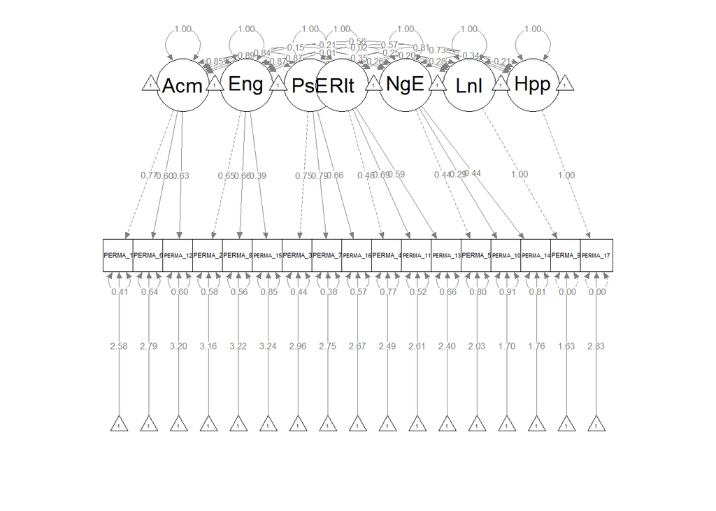

```r
semPaths(seven.fit, whatLabels = "std", layout = "tree")
```

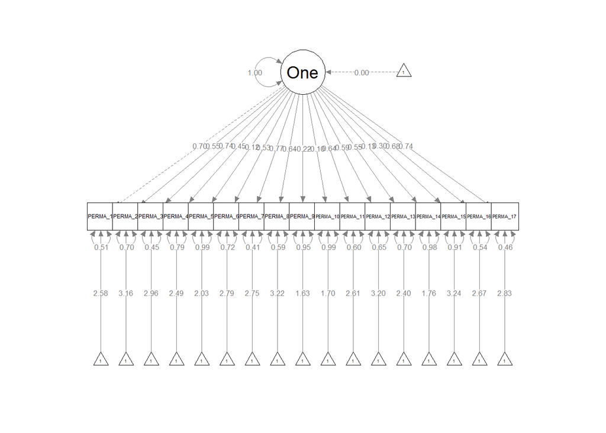

```r
semPaths(one.fit, whatLabels = "std", layout = "tree")
```

#summaries

```r
summary(seven.fit, standardized = TRUE, rsquare=TRUE)
```

```
## lavaan (0.5-18) converged normally after 200 iterations
##
##                                                   Used       Total
##   Number of observations                           237         670
##
##   Number of missing patterns                         1
##
##   Estimator                                         ML
##   Minimum Function Test Statistic              134.168
##   Degrees of freedom                               100
##   P-value (Chi-square)                           0.013
##
## Parameter estimates:
##
##   Information                                 Observed
##   Standard Errors                             Standard
##
##                    Estimate  Std.err  Z-value  P(>|z|)   Std.lv  Std.all
## Latent variables:
##   Acomplishment =~
##     PERMA_1           1.000                               1.921    0.765
##     PERMA_6           0.791    0.092    8.569    0.000    1.520    0.602
##     PERMA_12          0.802    0.089    8.981    0.000    1.541    0.632
##   Engagement =~
##     PERMA_2           1.000                               1.558    0.646
##     PERMA_8           0.997    0.127    7.847    0.000    1.553    0.664
##     PERMA_15          0.657    0.124    5.289    0.000    1.024    0.393
##   PositiveEmotion =~
##     PERMA_3           1.000                               1.739    0.747
##     PERMA_7           1.172    0.095   12.299    0.000    2.037    0.789
##     PERMA_16          0.920    0.093    9.879    0.000    1.599    0.658
##   Relationship =~
##     PERMA_4           1.000                               1.371    0.480
##     PERMA_11          1.443    0.225    6.416    0.000    1.979    0.689
##     PERMA_13          1.244    0.208    5.978    0.000    1.706    0.586
##   NegativeEmotion =~
##     PERMA_5           1.000                               1.424    0.443
##     PERMA_10          0.695    0.277    2.513    0.012    0.990    0.293
##     PERMA_14          1.027    0.437    2.353    0.019    1.463    0.438
##   Lonely =~
```

[output cut: 89 more lines]

```
##     PERMA_12          0.400
##     PERMA_2           0.418
##     PERMA_8           0.442
##     PERMA_15          0.154
##     PERMA_3           0.558
##     PERMA_7           0.622
##     PERMA_16          0.434
##     PERMA_4           0.230
##     PERMA_11          0.475
##     PERMA_13          0.343
##     PERMA_5           0.197
##     PERMA_10          0.086
##     PERMA_14          0.191
##     PERMA_9           1.000
##     PERMA_17          1.000
```

```r
summary(one.fit, standardized = TRUE, rsquare=TRUE)
```

```
## lavaan (0.5-18) converged normally after  40 iterations
##
##                                                   Used       Total
##   Number of observations                           237         670
##
##   Number of missing patterns                         1
##
##   Estimator                                         ML
##   Minimum Function Test Statistic              225.764
##   Degrees of freedom                               119
##   P-value (Chi-square)                           0.000
##
## Parameter estimates:
##
##   Information                                 Observed
##   Standard Errors                             Standard
##
##                    Estimate  Std.err  Z-value  P(>|z|)   Std.lv  Std.all
## Latent variables:
##   One =~
##     PERMA_1           1.000                               1.762    0.702
##     PERMA_2           0.754    0.095    7.953    0.000    1.329    0.551
##     PERMA_3           0.978    0.094   10.398    0.000    1.723    0.740
##     PERMA_4           0.734    0.111    6.592    0.000    1.294    0.453
##     PERMA_5          -0.220    0.125   -1.759    0.079   -0.387   -0.121
##     PERMA_6           0.756    0.098    7.704    0.000    1.332    0.527
##     PERMA_7           1.130    0.103   10.932    0.000    1.991    0.771
##     PERMA_8           0.848    0.092    9.251    0.000    1.494    0.639
##     PERMA_9          -0.467    0.145   -3.228    0.001   -0.823   -0.222
##     PERMA_10         -0.184    0.132   -1.399    0.162   -0.324   -0.096
##     PERMA_11          1.036    0.114    9.107    0.000    1.824    0.636
##     PERMA_12          0.816    0.095    8.567    0.000    1.437    0.589
##     PERMA_13          0.912    0.115    7.959    0.000    1.607    0.552
##     PERMA_14         -0.242    0.130   -1.859    0.063   -0.427   -0.128
##     PERMA_15          0.451    0.102    4.419    0.000    0.795    0.305
##     PERMA_16          0.932    0.096    9.741    0.000    1.641    0.676
##     PERMA_17          1.074    0.104   10.319    0.000    1.892    0.736
##
## Intercepts:
##     PERMA_1           6.485    0.163   39.775    0.000    6.485    2.584
```

[output cut: 42 more lines]

```
##     PERMA_3           0.548
##     PERMA_4           0.205
##     PERMA_5           0.015
##     PERMA_6           0.278
##     PERMA_7           0.595
##     PERMA_8           0.408
##     PERMA_9           0.049
##     PERMA_10          0.009
##     PERMA_11          0.404
##     PERMA_12          0.347
##     PERMA_13          0.304
##     PERMA_14          0.016
##     PERMA_15          0.093
##     PERMA_16          0.457
##     PERMA_17          0.542
```

# Residual correlations

```r
correl = residuals(seven.fit, type="cor")
correl
```

```
## $type
## [1] "cor.bollen"
##
## $cor
##          PERMA_1 PERMA_6 PERMA_12 PERMA_2 PERMA_8 PERMA_15 PERMA_3 PERMA_7
## PERMA_1   0.000
## PERMA_6   0.004   0.000
## PERMA_12 -0.005   0.002   0.000
## PERMA_2  -0.040  -0.021   0.026    0.000
## PERMA_8   0.064   0.025   0.044   -0.054   0.000
## PERMA_15 -0.104  -0.080  -0.057    0.138   0.001   0.000
## PERMA_3  -0.052  -0.047   0.003   -0.046   0.040  -0.030    0.000
## PERMA_7   0.009  -0.004   0.013   -0.037   0.041  -0.019    0.042   0.000
## PERMA_16  0.063   0.045  -0.006    0.021   0.008  -0.009   -0.018  -0.046
## PERMA_4   0.052  -0.033   0.018    0.030   0.019  -0.030   -0.095   0.047
## PERMA_11  0.002  -0.040  -0.066   -0.027   0.005  -0.081    0.019  -0.072
## PERMA_13  0.018   0.031   0.031    0.055  -0.019   0.054    0.058  -0.081
## PERMA_5   0.017   0.024  -0.032    0.017  -0.059   0.075    0.023   0.024
## PERMA_10 -0.043   0.041  -0.048   -0.009  -0.002   0.061   -0.072   0.039
## PERMA_14 -0.015   0.092  -0.024    0.065  -0.084   0.075   -0.056   0.015
## PERMA_9   0.031  -0.028  -0.029    0.072  -0.076   0.023    0.007   0.015
## PERMA_17  0.017  -0.070   0.032   -0.031   0.057  -0.072    0.012   0.007
##          PERMA_16 PERMA_4 PERMA_11 PERMA_13 PERMA_5 PERMA_10 PERMA_14
## PERMA_1
## PERMA_6
## PERMA_12
## PERMA_2
## PERMA_8
## PERMA_15
## PERMA_3
## PERMA_7
## PERMA_16  0.000
## PERMA_4   0.055    0.000
## PERMA_11  0.100   -0.020   0.000
## PERMA_13  0.063   -0.025   0.026    0.000
## PERMA_5  -0.037    0.035  -0.060    0.037    0.000
## PERMA_10 -0.036   -0.002  -0.003   -0.034    0.058   0.000
## PERMA_14  0.057    0.102  -0.024    0.016   -0.011  -0.039    0.000
## PERMA_9  -0.036    0.024  -0.034    0.033    0.003  -0.027    0.012
## PERMA_17 -0.031    0.003   0.035   -0.054    0.031   0.044   -0.058
```

[output cut: 11 more lines]

```
## PERMA_11
## PERMA_13
## PERMA_5
## PERMA_10
## PERMA_14
## PERMA_9   0.000
## PERMA_17  0.000   0.000
##
## $mean
##  PERMA_1  PERMA_6 PERMA_12  PERMA_2  PERMA_8 PERMA_15  PERMA_3  PERMA_7
##        0        0        0        0        0        0        0        0
## PERMA_16  PERMA_4 PERMA_11 PERMA_13  PERMA_5 PERMA_10 PERMA_14  PERMA_9
##        0        0        0        0        0        0        0        0
## PERMA_17
##        0
```

```r
View(correl$cor)
correl1 = residuals(one.fit, type="cor")
correl1
```

```
## $type
## [1] "cor.bollen"
##
## $cor
##          PERMA_1 PERMA_2 PERMA_3 PERMA_4 PERMA_5 PERMA_6 PERMA_7 PERMA_8
## PERMA_1   0.000
## PERMA_2  -0.004   0.000
## PERMA_3  -0.065  -0.034   0.000
## PERMA_4   0.042   0.049  -0.120   0.000
## PERMA_5   0.049   0.080  -0.003   0.034   0.000
## PERMA_6   0.095   0.020  -0.039  -0.029   0.047   0.000
## PERMA_7   0.004  -0.019   0.060   0.025  -0.005   0.010   0.000
## PERMA_8   0.050   0.023  -0.001   0.006   0.014   0.029   0.004   0.000
## PERMA_9   0.027   0.184  -0.018   0.028   0.102  -0.037  -0.014   0.055
## PERMA_10 -0.010   0.041  -0.077   0.005   0.176   0.064   0.032   0.057
## PERMA_11 -0.002   0.008  -0.006   0.023  -0.063  -0.027  -0.092  -0.005
## PERMA_12  0.065   0.050  -0.015   0.006  -0.004   0.072   0.000   0.026
## PERMA_13  0.007   0.079   0.028   0.006   0.037   0.035  -0.107  -0.035
## PERMA_14  0.023   0.132  -0.075   0.106   0.167   0.118  -0.007  -0.006
## PERMA_15 -0.061   0.224  -0.001  -0.005   0.110  -0.039   0.015   0.067
## PERMA_16  0.036   0.018  -0.027   0.022  -0.057   0.040  -0.047  -0.044
## PERMA_17 -0.072  -0.068   0.069   0.020  -0.031  -0.123   0.075  -0.035
##          PERMA_9 PERMA_10 PERMA_11 PERMA_12 PERMA_13 PERMA_14 PERMA_15
## PERMA_1
## PERMA_2
## PERMA_3
## PERMA_4
## PERMA_5
## PERMA_6
## PERMA_7
## PERMA_8
## PERMA_9   0.000
## PERMA_10  0.035   0.000
## PERMA_11 -0.032   0.005    0.000
## PERMA_12 -0.031  -0.020   -0.075    0.000
## PERMA_13  0.037  -0.026    0.079    0.017    0.000
## PERMA_14  0.108   0.076   -0.021    0.009    0.021    0.000
## PERMA_15  0.085   0.088   -0.041   -0.025    0.085    0.112    0.000
## PERMA_16 -0.053  -0.038    0.063   -0.036    0.024    0.043    0.009
## PERMA_17 -0.046   0.016    0.072   -0.049   -0.031   -0.112   -0.072
```

[output cut: 11 more lines]

```
## PERMA_11
## PERMA_12
## PERMA_13
## PERMA_14
## PERMA_15
## PERMA_16  0.000
## PERMA_17  0.002    0.000
##
## $mean
##  PERMA_1  PERMA_2  PERMA_3  PERMA_4  PERMA_5  PERMA_6  PERMA_7  PERMA_8
##        0        0        0        0        0        0        0        0
##  PERMA_9 PERMA_10 PERMA_11 PERMA_12 PERMA_13 PERMA_14 PERMA_15 PERMA_16
##        0        0        0        0        0        0        0        0
## PERMA_17
##        0
```

```r
View(correl1$cor)
```

# zscore correlation anything over 1.96 is going to be statistically significant at the .05 level

```r
zcorrels = residuals(seven.fit, type = "standardized")
View(zcorrels$cov)
zcorrels1 = residuals(one.fit, type = "standardized")
View(zcorrels1$cov)
```

# Modification indicies

```r
modindices(seven.fit, sort. = TRUE, minimum.value = 3.84)
```

```
##                lhs op      rhs     mi    epc sepc.lv sepc.all sepc.nox
## 1    Acomplishment =~  PERMA_8 14.005  1.085   2.084    0.892    0.892
## 2     Relationship =~ PERMA_16 13.571  1.491   2.044    0.842    0.842
## 3  PositiveEmotion =~  PERMA_8 12.667  0.826   1.436    0.614    0.614
## 4          PERMA_2 ~~ PERMA_15 12.522  1.184   1.184    0.188    0.188
## 5  NegativeEmotion =~  PERMA_8  9.005 -0.502  -0.714   -0.306   -0.306
## 6          PERMA_2 ~~  PERMA_8  8.970 -1.277  -1.277   -0.227   -0.227
## 7    Acomplishment =~ PERMA_15  8.685 -0.842  -1.617   -0.620   -0.620
## 8     Relationship =~  PERMA_7  8.147 -1.251  -1.716   -0.664   -0.664
## 9          PERMA_3 ~~  PERMA_4  8.065 -0.790  -0.790   -0.119   -0.119
## 10         PERMA_7 ~~ PERMA_11  7.182 -0.733  -0.733   -0.099   -0.099
## 11    Relationship =~  PERMA_8  6.389  0.881   1.208    0.517    0.517
## 12         PERMA_3 ~~  PERMA_7  5.919  0.603   0.603    0.100    0.100
## 13      Engagement =~ PERMA_11  5.551 -0.904  -1.408   -0.491   -0.491
## 14        PERMA_16 ~~ PERMA_11  5.490  0.672   0.672    0.096    0.096
```

[output cut: 18 more lines]

```r
modindices(one.fit, sort. = TRUE, minimum.value = 3.84)
```

```
##         lhs op      rhs     mi    epc sepc.lv sepc.all sepc.nox
## 1   PERMA_2 ~~ PERMA_15 19.996  1.497   1.497    0.238    0.238
## 2   PERMA_6 ~~ PERMA_17 13.196 -0.972  -0.972   -0.150   -0.150
## 3   PERMA_2 ~~  PERMA_9 12.803  1.738   1.738    0.194    0.194
## 4   PERMA_7 ~~ PERMA_13 12.281 -1.031  -1.031   -0.137   -0.137
## 5   PERMA_3 ~~  PERMA_4 11.461 -0.959  -0.959   -0.144   -0.144
## 6   PERMA_7 ~~ PERMA_11 11.118 -0.915  -0.915   -0.123   -0.123
## 7   PERMA_7 ~~ PERMA_17 10.735  0.742   0.742    0.112    0.112
## 8   PERMA_3 ~~ PERMA_17  7.794  0.587   0.587    0.098    0.098
## 9  PERMA_14 ~~ PERMA_17  7.597 -1.106  -1.106   -0.129   -0.129
## 10  PERMA_5 ~~ PERMA_10  7.515  1.916   1.916    0.176    0.176
## 11  PERMA_1 ~~ PERMA_17  7.229 -0.631  -0.631   -0.098   -0.098
## 12  PERMA_3 ~~  PERMA_7  6.968  0.540   0.540    0.090    0.090
## 13  PERMA_5 ~~ PERMA_14  6.877  1.805   1.805    0.168    0.168
## 14  PERMA_1 ~~  PERMA_6  6.848  0.710   0.710    0.112    0.112
## 15  PERMA_2 ~~ PERMA_14  6.315  1.117   1.117    0.139    0.139
## 16  PERMA_1 ~~  PERMA_3  5.927 -0.516  -0.516   -0.088   -0.088
## 17 PERMA_11 ~~ PERMA_17  5.757  0.680   0.680    0.092    0.092
## 18  PERMA_6 ~~ PERMA_14  4.897  1.046   1.046    0.124    0.124
## 19  PERMA_2 ~~ PERMA_17  4.234 -0.518  -0.518   -0.084   -0.084
## 20 PERMA_11 ~~ PERMA_13  4.110  0.760   0.760    0.091    0.091
## 21 PERMA_11 ~~ PERMA_12  4.017 -0.613  -0.613   -0.088   -0.088
```

# Fit Measures

```r
fitmeasures(seven.fit)
```

```
##                npar                fmin               chisq
##              70.000               0.283             134.168
##                  df              pvalue      baseline.chisq
##             100.000               0.013            1262.734
##         baseline.df     baseline.pvalue                 cfi
##             136.000               0.000               0.970
##                 tli                nnfi                 rfi
##               0.959               0.959               0.855
##                 nfi                pnfi                 ifi
##               0.894               0.657               0.971
##                 rni                logl   unrestricted.logl
##               0.970           -9211.899           -9144.815
##                 aic                 bic              ntotal
##           18563.797           18806.561             237.000
##                bic2               rmsea      rmsea.ci.lower
##           18584.686               0.038               0.018
##      rmsea.ci.upper        rmsea.pvalue                 rmr
##               0.054               0.889               0.311
##          rmr_nomean                srmr        srmr_bentler
##               0.327               0.041               0.041
## srmr_bentler_nomean         srmr_bollen  srmr_bollen_nomean
##               0.043               0.041               0.043
##          srmr_mplus   srmr_mplus_nomean               cn_05
##               0.041               0.043             220.644
##               cn_01                 gfi                agfi
##             240.895               0.988               0.979
##                pgfi                 mfi                ecvi
##               0.581               0.930                  NA
```

```r
fitmeasures(one.fit)
```

```
##                npar                fmin               chisq
##              51.000               0.476             225.764
##                  df              pvalue      baseline.chisq
##             119.000               0.000            1262.734
##         baseline.df     baseline.pvalue                 cfi
##             136.000               0.000               0.905
##                 tli                nnfi                 rfi
##               0.892               0.892               0.796
##                 nfi                pnfi                 ifi
##               0.821               0.719               0.907
##                 rni                logl   unrestricted.logl
##               0.905           -9257.697           -9144.815
##                 aic                 bic              ntotal
##           18617.393           18794.264             237.000
##                bic2               rmsea      rmsea.ci.lower
##           18632.612               0.062               0.049
##      rmsea.ci.upper        rmsea.pvalue                 rmr
##               0.074               0.062               0.460
##          rmr_nomean                srmr        srmr_bentler
##               0.485               0.055               0.055
## srmr_bentler_nomean         srmr_bollen  srmr_bollen_nomean
##               0.058               0.055               0.058
##          srmr_mplus   srmr_mplus_nomean               cn_05
##               0.055               0.058             153.700
##               cn_01                 gfi                agfi
##             166.653               0.982               0.974
##                pgfi                 mfi                ecvi
##               0.687               0.798                  NA
```

# Create dataset for Target rotation

```r
PermaTR<-select(data, PERMA_1  , PERMA_6 , PERMA_12, PERMA_2 ,  PERMA_8 , PERMA_15 ,PERMA_3 , PERMA_7 , PERMA_16 , PERMA_4 , PERMA_11 , PERMA_13 , PERMA_5 , PERMA_10 , PERMA_14, PERMA_9  , PERMA_17)
colnames(PermaTR) <- c("1","2", "3", "4", "5", "6", "7", "8", "9", "10", "11", "12", "13", "14", "15", "16", "17")
PermaTR<-tbl_df(PermaTR)
PermaTR
```

```
## Source: local data frame [670 x 17]
##
##    1  2  3 4  5  6  7 8 9 10 11 12 13 14 15 16 17
## 1  6  9  9 8  7  7  7 7 8  9 11  8  2 13  3 13  8
## 2  9  9 11 7 11  7  9 9 9 11 11 11 13  2 13  2 11
## 3  2 13  2 3  3  5  2 3 5  2  3  2 13 13  4  3  3
## 4  9  9 11 9  6 11  7 7 7  8  7  7  4  3 13  2  7
## 5  8  6  9 6  7  8  8 4 9  7 11  7  4  7  4  2  9
## 6  8  9  9 6  6  6  7 7 8  6  9  7  6  5  3  3  8
## 7  7  7  9 5  8  9  9 7 9  8 11 11  4  3  6  1  7
## 8  7  7 11 8  9  8 11 9 8  5  9  7  4  5  3  2  8
## 9  5  5  5 5  7  7  5 5 5  5  7  5  5  5  4  5  6
## 10 7  7  8 9  9  9  9 9 8 11  8  9  2  2  2  2  9
## .. . .. .. . .. .. .. . . .. .. .. .. .. .. .. ..
```

```r
#Target Roration
```

```r
Targ_key <- make.keys(17,list(f1=1:3,f2=4:6, f3=7:9, f4=10:12, f5=13:15, f6=16, f7=17))
Targ_key <- scrub(Targ_key,isvalue=1)  #fix the 0s, allow the NAs to be estimated
Targ_key <- list(Targ_key)
Perma_cor <- corFiml(PermaTR) # convert the raw data to correlation matrix uisng FIML
out_targetQ <- fa(Perma_cor,7,rotate="TargetQ", n.obs = 670, Target=Targ_key) #TargetT for orthogonal rotation
out_targetQ[c("loadings", "score.cor", "TLI", "RMSEA","uniquenesses")]
```

```
## $loadings
##
## Loadings:
##    MR1    MR3    MR2    MR4    MR5    MR7    MR6
## 1   0.846                                     0.480
## 2   0.887                             -0.147 -0.472
## 3   0.310  0.183  0.183
## 4                 0.665  0.156
## 5   0.246  0.217  0.201
## 6  -0.110  0.121  0.538
## 7          0.859         0.118
## 8   0.203  0.519  0.199 -0.228         0.395
## 9   0.227         0.141  0.326 -0.133  0.112
## 10  0.117 -0.101  0.211  0.165         0.317
## 11                       0.615         0.176
## 12  0.119         0.202  0.420
## 13         0.113                0.750
## 14        -0.103                0.304  0.171
## 15        -0.177  0.211         0.221
## 16 -0.105         0.238         0.133 -0.140  0.111
## 17         0.356         0.317         0.454
##
##                  MR1   MR3   MR2   MR4   MR5   MR7   MR6
## SS loadings    1.821 1.317 1.060 0.905 0.774 0.615 0.489
## Proportion Var 0.107 0.077 0.062 0.053 0.046 0.036 0.029
## Cumulative Var 0.107 0.185 0.247 0.300 0.346 0.382 0.411
##
## $score.cor
##            [,1]       [,2]       [,3]       [,4]        [,5]        [,6]
## [1,]  1.0000000  0.6517600 0.42209816  0.6238968 -0.14501702  0.37541828
## [2,]  0.6517600  1.0000000 0.40164102  0.6439615 -0.26258967  0.36262289
## [3,]  0.4220982  0.4016410 1.00000000  0.4427165  0.08837512  0.25891489
## [4,]  0.6238968  0.6439615 0.44271654  1.0000000 -0.21445272  0.37665465
## [5,] -0.1450170 -0.2625897 0.08837512 -0.2144527  1.00000000 -0.03506908
## [6,]  0.3754183  0.3626229 0.25891489  0.3766547 -0.03506908  1.00000000
##
## $TLI
## [1] 0.9694932
##
## $RMSEA
##      RMSEA      lower      upper confidence
## 0.03426712 0.01964488 0.04667311 0.10000000
##
## $uniquenesses
##           1           2           3           4           5           6
## 0.004999981 0.059650115 0.648825414 0.415489594 0.600265403 0.703317154
##           7           8           9          10          11          12
## 0.137827800 0.195878018 0.516483125 0.713541287 0.433101748 0.599760026
##          13          14          15          16          17
## 0.525056260 0.881583058 0.849595555 0.853397516 0.291440910
```

```r
out_targetQ
```

```
## Factor Analysis using method =  minres
## Call: fa(r = Perma_cor, nfactors = 7, n.obs = 670, rotate = "TargetQ",
##     Target = Targ_key)
## Standardized loadings (pattern matrix) based upon correlation matrix
##      MR1   MR3   MR2   MR4   MR5   MR7   MR6   h2    u2 com
## 1   0.85  0.01 -0.04  0.07 -0.02  0.03  0.48 1.00 0.005 1.6
## 2   0.89  0.02 -0.04  0.00  0.08 -0.15 -0.47 0.94 0.060 1.6
## 3   0.31  0.18  0.18  0.01 -0.10  0.03  0.02 0.35 0.649 2.6
## 4   0.04  0.04  0.66  0.16 -0.01 -0.04  0.01 0.58 0.415 1.1
## 5   0.25  0.22  0.20  0.08 -0.03  0.09  0.04 0.40 0.600 3.6
## 6  -0.11  0.12  0.54  0.02  0.07 -0.04  0.01 0.30 0.703 1.2
## 7   0.01  0.86  0.04  0.12 -0.03 -0.10  0.01 0.86 0.138 1.1
## 8   0.20  0.52  0.20 -0.23 -0.07  0.40 -0.04 0.80 0.196 3.1
## 9   0.23  0.05  0.14  0.33 -0.13  0.11 -0.02 0.48 0.516 3.0
## 10  0.12 -0.10  0.21  0.16 -0.01  0.32  0.02 0.29 0.714 2.9
## 11  0.06 -0.02  0.04  0.61 -0.08  0.18 -0.03 0.57 0.433 1.2
## 12  0.12  0.09  0.20  0.42  0.00 -0.09  0.00 0.40 0.600 1.9
## 13  0.05  0.11 -0.04  0.06  0.75  0.05  0.09 0.47 0.525 1.1
## 14  0.01 -0.10  0.02  0.00  0.30  0.17 -0.08 0.12 0.882 2.0
## 15  0.08 -0.18  0.21 -0.05  0.22 -0.07 -0.05 0.15 0.850 3.7
## 16 -0.10 -0.09  0.24 -0.09  0.13 -0.14  0.11 0.15 0.853 4.2
## 17 -0.06  0.36 -0.01  0.32 -0.04  0.45 -0.05 0.71 0.291 2.8
##
##                        MR1  MR3  MR2  MR4  MR5  MR7  MR6
## SS loadings           2.11 1.74 1.30 1.27 0.84 0.82 0.49
## Proportion Var        0.12 0.10 0.08 0.07 0.05 0.05 0.03
## Cumulative Var        0.12 0.23 0.30 0.38 0.43 0.48 0.50
## Proportion Explained  0.25 0.20 0.15 0.15 0.10 0.10 0.06
## Cumulative Proportion 0.25 0.45 0.60 0.75 0.85 0.94 1.00
##
##  With factor correlations of
##       MR1   MR3   MR2   MR4   MR5   MR7   MR6
## MR1  1.00  0.48  0.46  0.47 -0.25  0.38 -0.03
## MR3  0.48  1.00  0.34  0.55 -0.35  0.35  0.01
## MR2  0.46  0.34  1.00  0.35 -0.01  0.26  0.01
## MR4  0.47  0.55  0.35  1.00 -0.34  0.24  0.05
## MR5 -0.25 -0.35 -0.01 -0.34  1.00 -0.27 -0.04
## MR7  0.38  0.35  0.26  0.24 -0.27  1.00  0.10
## MR6 -0.03  0.01  0.01  0.05 -0.04  0.10  1.00
##
```

[output cut: 10 more lines]

```
## The total number of observations was  670  with MLE Chi Square =  66.72  with prob <  0.0027
##
## Tucker Lewis Index of factoring reliability =  0.969
## RMSEA index =  0.034  and the 90 % confidence intervals are  0.02 0.047
## BIC =  -180.56
## Fit based upon off diagonal values = 1
## Measures of factor score adequacy
##                                                 MR1  MR3  MR2  MR4  MR5
## Correlation of scores with factors             0.99 0.94 0.84 0.86 0.79
## Multiple R square of scores with factors       0.98 0.89 0.70 0.74 0.62
## Minimum correlation of possible factor scores  0.96 0.77 0.41 0.48 0.24
##                                                 MR7  MR6
## Correlation of scores with factors             0.83 0.96
## Multiple R square of scores with factors       0.69 0.93
## Minimum correlation of possible factor scores  0.38 0.86
```